# Inferential Statistics - Course Project 6

Maurizio Murino

25 January 2016

## Introduction

*In this project you will investigate the exponential distribution in R and compare it with the Central Limit Theorem. The exponential distribution can be simulated in R with rexp(n, lambda) where lambda is the rate parameter. The mean of exponential distribution is 1/lambda and the standard deviation is also 1/lambda. Set lambda = 0.2 for all of the simulations. You will investigate the distribution of averages of 40 exponentials. Note that you will need to do a thousand simulations.*

Illustrate via simulation and associated explanatory text the properties of the distribution of the mean of 40 exponentials.

## Simulations

*Include English explanations of the simulations you ran, with the accompanying R code.*

Set `lambda` to 0.2.

```r
lambda <- 0.2
```

I create a first data object `dt1` with a vectorized operation. When possible, I prefer this approach rather than a loop function. I set `set.seed(123)`.

```r
set.seed(123)
dt1 <- replicate(1000, mean(rexp(40, lambda)))
class(dt1)
```

```
## [1] "numeric"
```

## Sample Mean versus Theoretical Mean

*Include figures with titles. In the figures, highlight the means you are comparing. Include text that explains the figures and what is shown on them, and provides appropriate numbers.*

The sample mean is not very distant from the theoretical mean.

```r
s_mean <- mean(dt1)
th_mean <- 1/lambda
s_mean
```

```
## [1] 5.011911
```

```r
th_mean
```

```
## [1] 5
```

Now I am going to graphically compare the distribution of data `dt1` abouth the means.

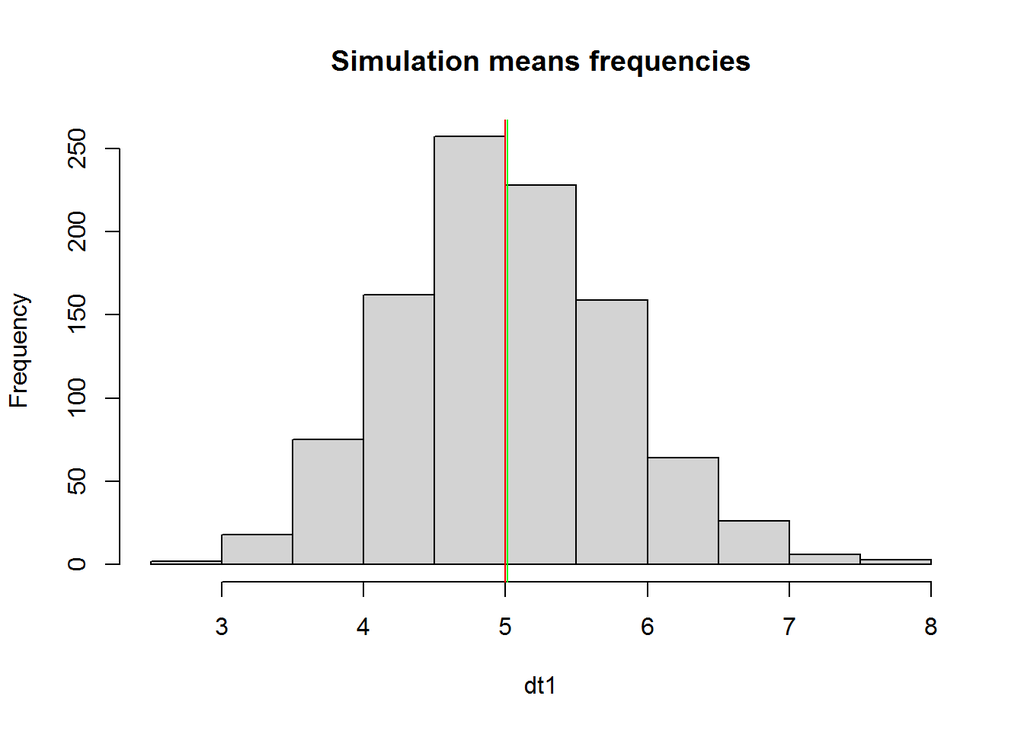

```r
hist(dt1, main = "Simulation means frequencies", col = "lightgray")
abline(v = s_mean, col = "green")
abline(v = th_mean, col = "red")
```

As anticipated after the calculation of the means, the deffirence between the sample mean and the theoretical mean is not relevant.

## Sample Variance versus Theoretical Variance

*Include figures (output from R) with titles. Highlight the variances you are comparing. Include text that explains your understanding of the differences of the variances.*

Comparison between sample variance and theoretical variance.

```r
s_var <- var(dt1)
th_var <- ((1/lambda)^2)/40
s_var
```

```
## [1] 0.6004928
```

```r
th_var
```

```
## [1] 0.625
```

## Distribution

*Via figures and text, explain how one can tell the distribution is approximately normal.*

As anticipated, variance and theoretical variance do not differ that much, hence variability is similar between to a normal distribution. That is maily due to the Central Limit Theorem. You can approximate the sample’s distribution with a normal distribution if the sample size is large enough.

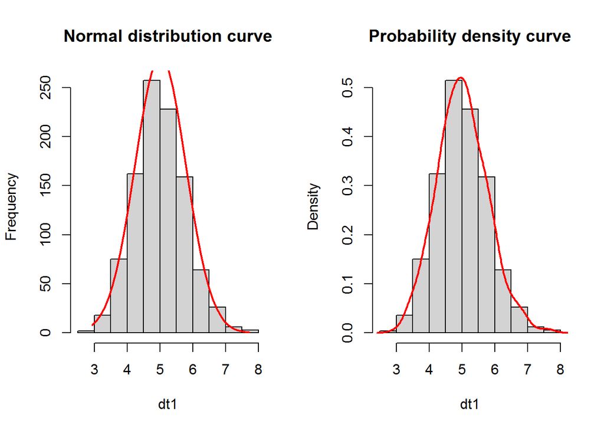

```r
# Add normal distribution line to hist

par(mfrow = c(1, 2))
h2 <- hist(dt1, col="lightgray", main="Normal distribution curve")
xfit<-seq(min(dt1),max(dt1),length=40)
yfit<-dnorm(xfit,mean=mean(dt1),sd=sd(dt1))
yfit <- yfit*diff(dt1[1:2])*length(dt1)
lines(xfit, yfit, col="red", lwd=2)

h1 <- hist(dt1, probability = TRUE, col = "lightgray", main = "Probability density curve")
lines(density(dt1), col = "red", lwd = 2)
```